# PD Frequentist Regression Analysis

Author

Carl Beuchel

Published

July 19, 2023

Main analysis:

- Global LR: TC ~ Variables + Regional-Effect
- Stratified per-region LR: TC ~ Variables
- Correlation TC ~ all variables
- GNI is not highly correlated to HDI –> use it as predictor
- FLB is not highly correlated to GI –> use it as predictor
- HDI ~ GI rho=-0.91
- AAG ~ GI rho=-0.81
- GDP ~ GI rho=-0.79

Select indices that do not correlate highly, focus on GI

- Choose GI over HDI –> GI is specific policy, HDI a meta aggregate (“develop your country” vs. “treat women better” as argument)
- Region strong confounder, **cannot** be ignored
- High correlation of GI with HDI, GDP, might be an influence

## 1 Load Data

```r
# Covid Testing/Vaccination data
data <- fread("data/clean-data/owid-data.tsv")

# MMR Vaccination data
mmr1 <- fread("data/owid/230606-MCV1-coverage-one-year-olds.csv")
mmr2 <- fread("data/owid/230606-MCV2-coverage-recommended-age.csv")
```

## 2 Global TC Regression Testing (2020/2021)

- Use scaled predictors to make effects comparable

```r
# scaled data
data_scaled <- copy(data)
data_scaled <- data_scaled[, .(
  Testing20,
  Testing21,
  GBDR7,
  CHE = c(scale(CHE)),
  UP = c(scale(UP)),
  log_PD = c(scale(log_PD)),
  EP = c(scale(EP)),
  GI = c(scale(GI)),
  Gini = c(scale(Gini)),
  VE = c(scale(VE))
)]

# Don't use the scaled GI, not necessary
non_correlated_indices <- c("CHE", "UP", "log_PD", "EP", "GI", "Gini", "VE")

# Create a factor for GBDR7 to set reference factor in model to high-income
data_scaled$GBDR7_f <- relevel(factor(data_scaled$GBDR7), 2)
```

Fit the model

```r
# Main Model Formula
model_formula_20 <- paste0("Testing20 ~ 1 + GBDR7_f + ", paste(non_correlated_indices, collapse = " + "))
model_formula_21 <- paste0("Testing21 ~ 1 + GBDR7_f + ", paste(non_correlated_indices, collapse = " + "))

# Model fit (including dispersion parameter theta estimation)
mod_negbin_20 <- glm.nb(formula = model_formula_20, data = data_scaled)
mod_negbin_21 <- glm.nb(formula = model_formula_21, data = data_scaled)

# Summary of each model to
mod_negbin_21  |> tidy(conf.int = TRUE, exponentiate = TRUE) |> kable()
```

| term | estimate | std.error | statistic | p.value | conf.low | conf.high |
| --- | --- | --- | --- | --- | --- | --- |
| (Intercept) | 1.713348e+05 | 0.3131074 | 38.4895867 | 0.0000000 | 9.385706e+04 | 3.213171e+05 |
| GBDR7_fCentral Europe, Eastern Europe, and Central Asia | 7.086384e-01 | 0.3207287 | -1.0738355 | 0.2828964 | 3.843458e-01 | 1.314505e+00 |
| GBDR7_fLatin America and Caribbean | 1.494278e-01 | 0.4891783 | -3.8859909 | 0.0001019 | 5.497000e-02 | 4.060807e-01 |
| GBDR7_fNorth Africa and Middle East | 5.827236e-01 | 0.4753693 | -1.1360478 | 0.2559366 | 2.281487e-01 | 1.528670e+00 |
| GBDR7_fSoutheast Asia, East Asia, and Oceania | 3.222378e-01 | 0.5920438 | -1.9128071 | 0.0557727 | 1.082828e-01 | 9.724837e-01 |
| GBDR7_fSub-Saharan Africa | 8.359710e-02 | 0.6595171 | -3.7629745 | 0.0001679 | 2.272710e-02 | 3.062475e-01 |
| CHE | 9.363750e-01 | 0.1218087 | -0.5396927 | 0.5894090 | 7.361716e-01 | 1.199441e+00 |
| UP | 8.398097e-01 | 0.1618212 | -1.0788446 | 0.2806570 | 6.087456e-01 | 1.156350e+00 |
| log_PD | 1.034744e+00 | 0.0917814 | 0.3721222 | 0.7098019 | 8.511448e-01 | 1.253719e+00 |
| EP | 1.274869e+00 | 0.0967005 | 2.5112955 | 0.0120289 | 1.043939e+00 | 1.553112e+00 |
| GI | 7.375612e-01 | 0.2397279 | -1.2697987 | 0.2041563 | 4.454923e-01 | 1.232507e+00 |
| Gini | 1.198532e+00 | 0.1318931 | 1.3730637 | 0.1697326 | 9.185421e-01 | 1.560465e+00 |
| VE | 5.363218e-01 | 0.1800828 | -3.4596360 | 0.0005409 | 3.797708e-01 | 7.569030e-01 |

```r
mod_negbin_20  |> tidy(conf.int = TRUE, exponentiate = TRUE) |> kable()
```

| term | estimate | std.error | statistic | p.value | conf.low | conf.high |
| --- | --- | --- | --- | --- | --- | --- |
| (Intercept) | 2.581987e+04 | 0.2444250 | 41.5624413 | 0.0000000 | 1.571974e+04 | 4.316675e+04 |
| GBDR7_fCentral Europe, Eastern Europe, and Central Asia | 8.753310e-01 | 0.2503717 | -0.5318220 | 0.5948493 | 5.273318e-01 | 1.452487e+00 |
| GBDR7_fLatin America and Caribbean | 3.712853e-01 | 0.3818785 | -2.5945019 | 0.0094728 | 1.668864e-01 | 8.251505e-01 |
| GBDR7_fNorth Africa and Middle East | 9.329745e-01 | 0.3710893 | -0.1869560 | 0.8516952 | 4.518607e-01 | 1.956703e+00 |
| GBDR7_fSoutheast Asia, East Asia, and Oceania | 7.517575e-01 | 0.4621797 | -0.6173822 | 0.5369827 | 2.838640e-01 | 1.995069e+00 |
| GBDR7_fSub-Saharan Africa | 3.257132e-01 | 0.5148697 | -2.1786835 | 0.0293552 | 1.128977e-01 | 9.351854e-01 |
| CHE | 9.749280e-01 | 0.0950907 | -0.2670258 | 0.7894493 | 8.218331e-01 | 1.161327e+00 |
| UP | 1.209550e+00 | 0.1263329 | 1.5059302 | 0.1320851 | 9.211808e-01 | 1.580526e+00 |
| log_PD | 1.102053e+00 | 0.0716503 | 1.3562403 | 0.1750227 | 9.578388e-01 | 1.265689e+00 |
| EP | 1.145381e+00 | 0.0754974 | 1.7979059 | 0.0721919 | 9.846791e-01 | 1.330691e+00 |
| GI | 7.211872e-01 | 0.1871478 | -1.7465155 | 0.0807214 | 4.868390e-01 | 1.076451e+00 |
| Gini | 1.146378e+00 | 0.1029727 | 1.3266352 | 0.1846294 | 9.433245e-01 | 1.390396e+00 |
| VE | 5.688652e-01 | 0.1405923 | -4.0123950 | 0.0000601 | 4.316229e-01 | 7.491869e-01 |

```r
# Model info
broom::glance(mod_negbin_20) |> kable()
```

| null.deviance | df.null | logLik | AIC | BIC | deviance | df.residual | nobs |
| --- | --- | --- | --- | --- | --- | --- | --- |
| 420.3935 | 108 | -1155.329 | 2338.659 | 2376.338 | 116.6298 | 96 | 109 |

```r
broom::glance(mod_negbin_21) |> kable()
```

| null.deviance | df.null | logLik | AIC | BIC | deviance | df.residual | nobs |
| --- | --- | --- | --- | --- | --- | --- | --- |
| 339.4991 | 108 | -1317.158 | 2662.315 | 2699.994 | 121.2131 | 96 | 109 |

```r
# Print dispersion parameter
mod_negbin_20$theta
```

```
[1] 2.340008
```

```r
mod_negbin_21$theta
```

```
[1] 1.42581
```

```r
# Save the coefficients
mod_negbin_20_coefs <- cbind(
  mod_negbin_20 |> tidy() |> as.data.table(),
  confint(mod_negbin_20)
)
mod_negbin_21_coefs <- cbind(
  mod_negbin_21 |> tidy() |> as.data.table(),
  confint(mod_negbin_21)
)

# join data for plotting
mod_negbin_20_coefs[, year := "2020"]
mod_negbin_21_coefs[, year := "2021"]
mod_negbin_coefs <- rbindlist(list(mod_negbin_20_coefs,
                                   mod_negbin_21_coefs))

# Transform estimates and CI to Incidence Rate Ratio (% increase/decrease from base)
mod_negbin_coefs[, `:=`(exp_estimate = exp(estimate),
                        exp_2_5 = exp(`2.5 %`),
                        exp_97_5 = exp(`97.5 %`))]

# Calculate the relative change in testing by each predictor increase
mod_negbin_coefs[, `:=`(rel_change  = exp_estimate - 1,
                        rel_change_2_5 = exp_2_5 - 1,
                        rel_change_97_5 = exp_97_5 - 1)]

# Create ordered factor to improve plotting
mod_negbin_coefs[, term := factor(
  term,
  ordered = T,
  levels = c(
    "(Intercept)",
    "GBDR7_fCentral Europe, Eastern Europe, and Central Asia",
    "GBDR7_fLatin America and Caribbean",
    "GBDR7_fNorth Africa and Middle East",
    "GBDR7_fSoutheast Asia, East Asia, and Oceania",
    "GBDR7_fSub-Saharan Africa",
    "CHE",
    "GI",
    "Gini",
    "VE",
    "EP",
    "log_PD",
    "UP"
  ) |> rev(),
  labels = c(
    "(Intercept)",
    "GBDR7\n(Central/Eastern Europe, and Central Asia)",
    "GBDR7\n(Latin America and Caribbean)",
    "GBDR7\n(North Africa and Middle East)",
    "GBDR7\n(Southeast Asia, East Asia, and Oceania)",
    "GBDR7\n(Sub-Saharan Africa)",
    "CHE",
    "GI",
    "Gini",
    "VE",
    "EP",
    "log(PD)",
    "UP"
  ) |> rev()
)]

# create dummy factor for facetting
mod_negbin_coefs[, facet_dum := ifelse(grepl("GBDR7|Intercept", term), "A", "B")]
```

Print the results with convenient rounding.

```r
mod_negbin_coefs[, lapply(.SD, function(x){
  if(is.numeric(x))
    return(format(signif(x,2),scientific=F))
  else
    return(x)
}
)] |> kable()
```

| term | estimate | std.error | statistic | p.value | 2.5 % | 97.5 % | year | exp_estimate | exp_2_5 | exp_97_5 | rel_change | rel_change_2_5 | rel_change_97_5 | facet_dum |
| --- | --- | --- | --- | --- | --- | --- | --- | --- | --- | --- | --- | --- | --- | --- |
| (Intercept) | 10.000 | 0.240 | 42.00 | 0.00000 | 9.700 | 11.000 | 2020 | 26000.000 | 16000.000 | 43000.00 | 26000.000 | 16000.000 | 43000.000 | A |
| GBDR7 (Central/Eastern Europe, and Central Asia) | -0.130 | 0.250 | -0.53 | 0.59000 | -0.640 | 0.370 | 2020 | 0.880 | 0.530 | 1.50 | -0.120 | -0.470 | 0.450 | A |
| GBDR7 (Latin America and Caribbean) | -0.990 | 0.380 | -2.60 | 0.00950 | -1.800 | -0.190 | 2020 | 0.370 | 0.170 | 0.83 | -0.630 | -0.830 | -0.170 | A |
| GBDR7 (North Africa and Middle East) | -0.069 | 0.370 | -0.19 | 0.85000 | -0.790 | 0.670 | 2020 | 0.930 | 0.450 | 2.00 | -0.067 | -0.550 | 0.960 | A |
| GBDR7 (Southeast Asia, East Asia, and Oceania) | -0.290 | 0.460 | -0.62 | 0.54000 | -1.300 | 0.690 | 2020 | 0.750 | 0.280 | 2.00 | -0.250 | -0.720 | 1.000 | A |
| GBDR7 (Sub-Saharan Africa) | -1.100 | 0.510 | -2.20 | 0.02900 | -2.200 | -0.067 | 2020 | 0.330 | 0.110 | 0.94 | -0.670 | -0.890 | -0.065 | A |
| CHE | -0.025 | 0.095 | -0.27 | 0.79000 | -0.200 | 0.150 | 2020 | 0.970 | 0.820 | 1.20 | -0.025 | -0.180 | 0.160 | B |
| UP | 0.190 | 0.130 | 1.50 | 0.13000 | -0.082 | 0.460 | 2020 | 1.200 | 0.920 | 1.60 | 0.210 | -0.079 | 0.580 | B |
| log(PD) | 0.097 | 0.072 | 1.40 | 0.18000 | -0.043 | 0.240 | 2020 | 1.100 | 0.960 | 1.30 | 0.100 | -0.042 | 0.270 | B |
| EP | 0.140 | 0.075 | 1.80 | 0.07200 | -0.015 | 0.290 | 2020 | 1.100 | 0.980 | 1.30 | 0.150 | -0.015 | 0.330 | B |
| GI | -0.330 | 0.190 | -1.70 | 0.08100 | -0.720 | 0.074 | 2020 | 0.720 | 0.490 | 1.10 | -0.280 | -0.510 | 0.076 | B |
| Gini | 0.140 | 0.100 | 1.30 | 0.18000 | -0.058 | 0.330 | 2020 | 1.100 | 0.940 | 1.40 | 0.150 | -0.057 | 0.390 | B |
| VE | -0.560 | 0.140 | -4.00 | 0.00006 | -0.840 | -0.290 | 2020 | 0.570 | 0.430 | 0.75 | -0.430 | -0.570 | -0.250 | B |
| (Intercept) | 12.000 | 0.310 | 38.00 | 0.00000 | 11.000 | 13.000 | 2021 | 170000.000 | 94000.000 | 320000.00 | 170000.000 | 94000.000 | 320000.000 | A |
| GBDR7 (Central/Eastern Europe, and Central Asia) | -0.340 | 0.320 | -1.10 | 0.28000 | -0.960 | 0.270 | 2021 | 0.710 | 0.380 | 1.30 | -0.290 | -0.620 | 0.310 | A |
| GBDR7 (Latin America and Caribbean) | -1.900 | 0.490 | -3.90 | 0.00010 | -2.900 | -0.900 | 2021 | 0.150 | 0.055 | 0.41 | -0.850 | -0.950 | -0.590 | A |
| GBDR7 (North Africa and Middle East) | -0.540 | 0.480 | -1.10 | 0.26000 | -1.500 | 0.420 | 2021 | 0.580 | 0.230 | 1.50 | -0.420 | -0.770 | 0.530 | A |
| GBDR7 (Southeast Asia, East Asia, and Oceania) | -1.100 | 0.590 | -1.90 | 0.05600 | -2.200 | -0.028 | 2021 | 0.320 | 0.110 | 0.97 | -0.680 | -0.890 | -0.028 | A |
| GBDR7 (Sub-Saharan Africa) | -2.500 | 0.660 | -3.80 | 0.00017 | -3.800 | -1.200 | 2021 | 0.084 | 0.023 | 0.31 | -0.920 | -0.980 | -0.690 | A |
| CHE | -0.066 | 0.120 | -0.54 | 0.59000 | -0.310 | 0.180 | 2021 | 0.940 | 0.740 | 1.20 | -0.064 | -0.260 | 0.200 | B |
| UP | -0.170 | 0.160 | -1.10 | 0.28000 | -0.500 | 0.150 | 2021 | 0.840 | 0.610 | 1.20 | -0.160 | -0.390 | 0.160 | B |
| log(PD) | 0.034 | 0.092 | 0.37 | 0.71000 | -0.160 | 0.230 | 2021 | 1.000 | 0.850 | 1.30 | 0.035 | -0.150 | 0.250 | B |
| EP | 0.240 | 0.097 | 2.50 | 0.01200 | 0.043 | 0.440 | 2021 | 1.300 | 1.000 | 1.60 | 0.270 | 0.044 | 0.550 | B |
| GI | -0.300 | 0.240 | -1.30 | 0.20000 | -0.810 | 0.210 | 2021 | 0.740 | 0.450 | 1.20 | -0.260 | -0.550 | 0.230 | B |
| Gini | 0.180 | 0.130 | 1.40 | 0.17000 | -0.085 | 0.440 | 2021 | 1.200 | 0.920 | 1.60 | 0.200 | -0.081 | 0.560 | B |
| VE | -0.620 | 0.180 | -3.50 | 0.00054 | -0.970 | -0.280 | 2021 | 0.540 | 0.380 | 0.76 | -0.460 | -0.620 | -0.240 | B |

Save as result.

```r
fwrite(
  x = mod_negbin_coefs[, .(
    Predictor = term,
    effect_estimate = estimate,
    standard_error = std.error,
    test_statistic = statistic,
    p_value = p.value,
    confidence_interval_lower = `2.5 %`,
    confidence_interval_upper = `97.5 %`,
    relative_change = format(rel_change, scientific = F),
    relative_change_lower_ci = format(rel_change_2_5, scientific = F),
    relative_change_upper_ci = format(rel_change_97_5, scientific = F)
  )],
  file = "paper/tables/tc_global_regression_sumstats.csv",
  sep = ","
)
```

### 2.1 Forestplot

Plot the results. Reference group for the Region effects is “High-Income”. Displayed effects are independent of region and other indices and represent a global trend.

```r
# Custom breaks for the x axis to make effect size clear
b <- seq(-150, 150, 25)

# Custom forest plot
p <- ggplot(mod_negbin_coefs[term != "(Intercept)"],
            aes(color = year,
                y = term)
) +
  facet_wrap(~facet_dum, scales = "free_y") +
  geom_point(aes(x = rel_change * 100,
                 group = year),
             position = position_dodge2(width = 0.8, reverse = TRUE),
             shape = 15,
             size = 3
  ) +
  geom_linerange(aes(xmin = rel_change_2_5 * 100,
                     xmax = rel_change_97_5 * 100,
                     group = year),
                 position = position_dodge2(width = 0.8, reverse = TRUE)
  ) +
  geom_vline(xintercept = 0,
             linetype = "dashed") +
  guides(color = guide_legend(title = "Year")) +
  labs(x = "Relative Change in Testing Capacity [%]", y = "") +
  scale_x_continuous(breaks = b) +
  theme(legend.position = "bottom",
        strip.text = element_blank(),
        plot.background = element_rect(fill = "white"),
        axis.text.x = element_text(size = 10))
```

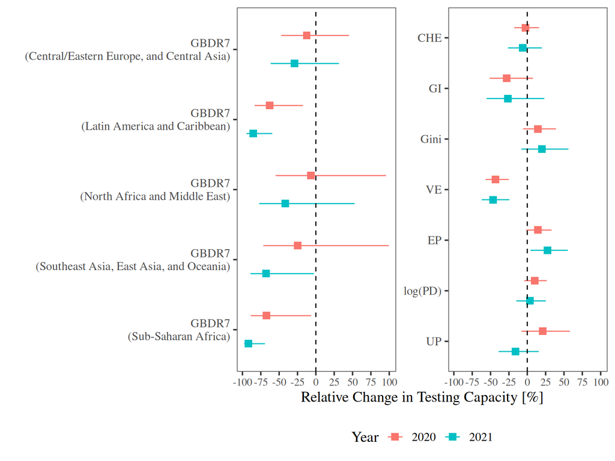

```r
print(p)
```

```r
ggsave(p,
       filename = "tc_global_forestplot.tiff",
       path = "paper/figures/",
       device = "tiff",
       width = 9,
       height = 4,
       dpi = 150)
```

### 2.2 Predict changes in TC

Plot fit predictions for GI using add_ci.negbin for 2020 Predictions

```r
# Use the fits to predict values for each year
model_list <- list(
  "2020" = mod_negbin_20,
  "2021" = mod_negbin_21
)

# Avoid nested list and create single grid for looping
test_plan <- expand.grid(
  year = c("2020", "2021"),
  indices = non_correlated_indices,
  stringsAsFactors = FALSE
)
setDT(test_plan)
test_plan <- test_plan[order(year, indices)]
test_plan[, run_index := .I]

# Save all CI and PI predictions for each index in a list
res_ci_pi <- vector("list", length(non_correlated_indices))
names(res_ci_pi) <- non_correlated_indices

# Save results for later plotting
result_list <- list(
  "2020" = res_ci_pi,
  "2021" = res_ci_pi
)
```

Loop through each index and year to create predictions

```r
for (test_plan_i in test_plan$run_index) {

  # test_plan_i <- 1
  i <- test_plan[run_index == (test_plan_i), indices]
  my_year <- test_plan[run_index == (test_plan_i), year]

  new_dat <- data.table(
    GBDR7_f = rep(levels(data_scaled$GBDR7_f),each = 30),
    Testing20 = as.numeric(0),
    Testing21 = as.numeric(0)
  )
  set(new_dat, j = i, value = rep(seq(-3,3, length.out = 30),
                                  times = uniqueN(data_scaled$GBDR7)))
  set(new_dat, j = non_correlated_indices[non_correlated_indices != i], value = 0)

  # Add CI for constant predictors except GI
  new_dat_ci <- add_ci(new_dat,
                       fit = model_list[[my_year]],
                       yhatName = "ci_pred",
                       names = c("lcb", "ucb")
  )

  # Temporarily set Predictors to non-zero to make the function work (I'm sorry it sucks)
  new_dat_ci <- cbind(
    new_dat_ci,
    my_add_pi(df = new_dat,
              fit = model_list[[my_year]],
              yhatName = "pi_pred",
              additional_i = non_correlated_indices[non_correlated_indices != i],
              names = c("lpb", "upb")
    )[, c("pi_pred", "lpb", "upb")])

  setDT(new_dat_ci)
  new_dat_ci[, pred_index := (i)]

  # Remove Mock variables
  new_dat_ci$Testing20 <- NULL
  new_dat_ci$Testing21 <- NULL

  # Save predictions for year and index
  result_list[[my_year]][[i]] <- new_dat_ci

}
```

Consolidate Results

```r
# For 2020
res_ci_pi_2020 <- rbindlist(result_list[["2020"]], use.names = TRUE)
res_ci_pi_2020[, index_range := rep(
  seq(-3,3, length.out = 30),
  times = uniqueN(data_scaled$GBDR7) * uniqueN(non_correlated_indices)
)
]
res_ci_pi_2020[, Year := ("2020")]

# For 2021
res_ci_pi_2021 <- rbindlist(result_list[["2021"]], use.names = TRUE)
res_ci_pi_2021[, index_range := rep(
  seq(-3,3, length.out = 30),
  times = uniqueN(data_scaled$GBDR7) * uniqueN(non_correlated_indices)
)
]
res_ci_pi_2021[, Year := ("2021")]

# Join
res_ci_pi <- rbindlist(list(res_ci_pi_2020, res_ci_pi_2021))
```

Save prediction results

```r
fwrite(
  x = res_ci_pi[, .(
    Year,
    GBDR7 = GBDR7_f,
    Predictor = pred_index,
    Predictor_value = index_range,
    predicted_value = ci_pred,
    confidence_interval_lower = lcb,
    confidence_interval_upper = ucb,
    prediction_interval_lower = lpb,
    prediction_interval_upper = upb
  )],
  file = "paper/tables/tc_global_prediction_results.csv",
  sep = ","
)
```

Plot predictions for 2020

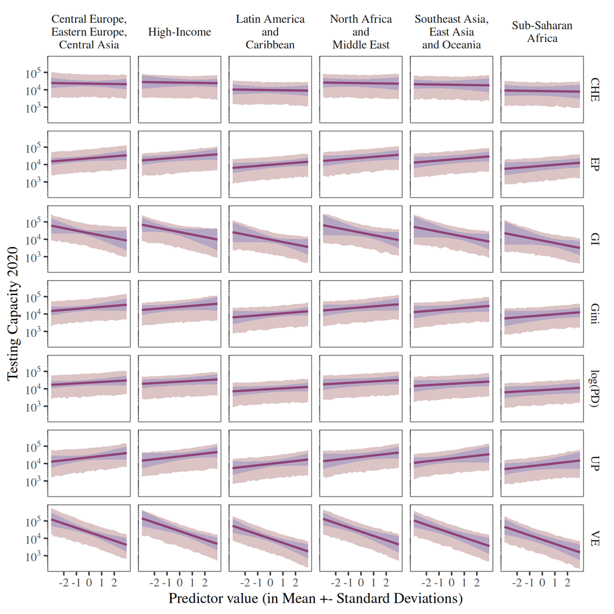

```r
p1 <- ggplot(res_ci_pi[Year == "2020"],
             aes(x = index_range, y = ci_pred)) +
  facet_grid(
    pred_index~GBDR7_f,
    labeller = labeller(
      .rows =  c(CHE = "CHE", UP = "UP",
                 log_PD = "log(PD)", EP = "EP",
                 GI = "GI", Gini = "Gini", VE = "VE"),
      .cols = c(
        "High-Income" = "High-Income",
        "Central Europe, Eastern Europe, and Central Asia" = "Central Europe,\nEastern Europe,\nCentral Asia",
        "Latin America and Caribbean" = "Latin America\nand\nCaribbean",
        "North Africa and Middle East" = "North Africa\nand\nMiddle East",
        "Southeast Asia, East Asia, and Oceania" = "Southeast Asia,\nEast Asia\nand Oceania",
        "Sub-Saharan Africa" = "Sub-Saharan\nAfrica"
      )
    )
  ) +
  scale_x_continuous(breaks = -2:2) +
  scale_y_continuous(
    trans = "log10",
    labels = trans_format("log10",
                          math_format(10^.x))) +
  annotation_logticks(sides = "l",
                      outside = T,
                      long = grid::unit(1.5, "mm"),
                      mid = grid::unit(1.1, "mm"),
                      short = grid::unit(.8, "mm")
  ) +
  geom_line(aes(y = ci_pred), lwd = 1, color = "maroon") +
  geom_ribbon(aes(ymin = lcb, ymax = ucb), fill = "royalblue1", alpha = 0.3) +
  geom_ribbon(aes(ymin = lpb, ymax = upb), fill = "indianred4", alpha = 0.3) +
  # scale_y_continuous(labels = function(x) format(x, scientific = FALSE)) +
  xlab("Predictor value (in Mean +- Standard Deviations)") +
  ylab("Testing Capacity 2020")

p2 <- ggplot(res_ci_pi[Year == "2020"],
             aes(x = index_range, y = ci_pred)) +
  facet_grid(
    pred_index~GBDR7_f,
    labeller = labeller(
      .rows =  c(CHE = "CHE", UP = "UP",
                 log_PD = "log(PD)", EP = "EP",
                 GI = "GI", Gini = "Gini", VE = "VE"),
      .cols = c(
        "High-Income" = "High-Income",
        "Central Europe, Eastern Europe, and Central Asia" = "Central Europe,\nEastern Europe,\nCentral Asia",
        "Latin America and Caribbean" = "Latin America\nand\nCaribbean",
        "North Africa and Middle East" = "North Africa\nand\nMiddle East",
        "Southeast Asia, East Asia, and Oceania" = "Southeast Asia,\nEast Asia\nand Oceania",
        "Sub-Saharan Africa" = "Sub-Saharan\nAfrica"
      )
    )
  ) +
  scale_x_continuous(breaks = -2:2) +
  scale_y_continuous(labels = scales::label_number()) +
  geom_line(aes(y = ci_pred), lwd = 1, color = "maroon") +
  geom_ribbon(aes(ymin = lcb, ymax = ucb), fill = "royalblue1", alpha = 0.3) +
  geom_ribbon(aes(ymin = lpb, ymax = upb), fill = "indianred4", alpha = 0.3) +
  # scale_y_continuous(labels = function(x) format(x, scientific = FALSE)) +
  xlab("Predictor value (in Mean +- Standard Deviations)") +
  ylab("Testing Capacity 2020")

print(p1)
```

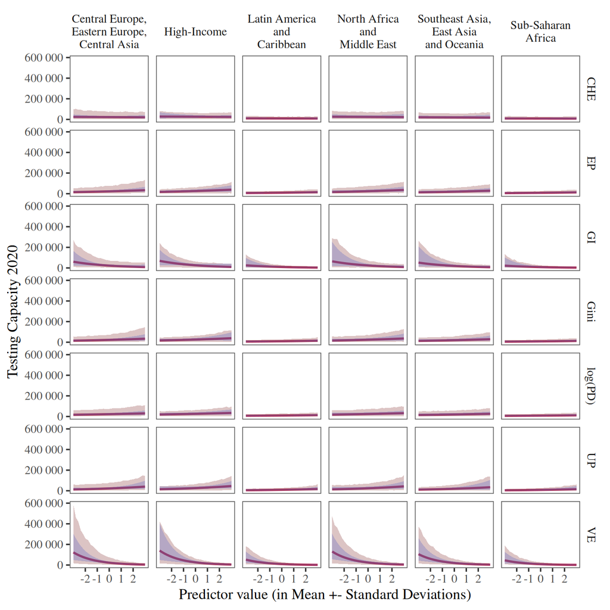

```r
print(p2)
```

Save 2020 plots

```r
ggsave(p1,
       filename = "2020_tc_global_prediction_log.tiff",
       path = "paper/figures/",
       device = "tiff",
       width = 9,
       height = 9,
       dpi = 150)

ggsave(p2,
       filename = "2020_tc_global_prediction_linear.tiff",
       path = "paper/figures/",
       device = "tiff",
       width = 9,
       height = 9,
       dpi = 150)
```

```r
p3 <- ggplot(res_ci_pi[Year == "2021"], aes(x = index_range, y = ci_pred))  +
  facet_grid(
    pred_index~GBDR7_f,
    labeller = labeller(
      .rows =  c(CHE = "CHE", UP = "UP",
                 log_PD = "log(PD)", EP = "EP",
                 GI = "GI", Gini = "Gini", VE = "VE"),
      .cols = c(
        "High-Income" = "High-Income",
        "Central Europe, Eastern Europe, and Central Asia" = "Central Europe,\nEastern Europe,\nCentral Asia",
        "Latin America and Caribbean" = "Latin America\nand\nCaribbean",
        "North Africa and Middle East" = "North Africa\nand\nMiddle East",
        "Southeast Asia, East Asia, and Oceania" = "Southeast Asia,\nEast Asia\nand Oceania",
        "Sub-Saharan Africa" = "Sub-Saharan\nAfrica"
      )
    )
  ) +
  scale_y_continuous(
    trans = "log10",
    labels = trans_format("log10",
                          math_format(10^.x))) +
  annotation_logticks(sides = "l",
                      outside = T,
                      long = grid::unit(1.5, "mm"),
                      mid = grid::unit(1.1, "mm"),
                      short = grid::unit(.8, "mm")
  ) +
  scale_x_continuous(breaks = -2:2) +
  geom_line(aes(y = ci_pred), lwd = 1, color = "maroon") +
  geom_ribbon(aes(ymin = lcb, ymax = ucb), fill = "royalblue1", alpha = 0.3) +
  geom_ribbon(aes(ymin = lpb, ymax = upb), fill = "indianred4", alpha = 0.3) +
  # scale_y_continuous(labels = function(x) format(x, scientific = FALSE)) +
  xlab("Predictor value (in Mean +- Standard Deviations)") +
  ylab("Testing Capacity 2021")

p4 <- ggplot(res_ci_pi[Year == "2021"], aes(x = index_range, y = ci_pred))  +
  facet_grid(
    pred_index~GBDR7_f,
    labeller = labeller(
      .rows =  c(CHE = "CHE", UP = "UP",
                 log_PD = "log(PD)", EP = "EP",
                 GI = "GI", Gini = "Gini", VE = "VE"),
      .cols = c(
        "High-Income" = "High-Income",
        "Central Europe, Eastern Europe, and Central Asia" = "Central Europe,\nEastern Europe,\nCentral Asia",
        "Latin America and Caribbean" = "Latin America\nand\nCaribbean",
        "North Africa and Middle East" = "North Africa\nand\nMiddle East",
        "Southeast Asia, East Asia, and Oceania" = "Southeast Asia,\nEast Asia\nand Oceania",
        "Sub-Saharan Africa" = "Sub-Saharan\nAfrica"
      )
    )
  ) +
  scale_y_continuous(labels =  scales::label_number()) +
  scale_x_continuous(breaks = -2:2) +
  geom_line(aes(y = ci_pred), lwd = 1, color = "maroon") +
  geom_ribbon(aes(ymin = lcb, ymax = ucb), fill = "royalblue1", alpha = 0.3) +
  geom_ribbon(aes(ymin = lpb, ymax = upb), fill = "indianred4", alpha = 0.3) +
  # scale_y_continuous(labels = function(x) format(x, scientific = FALSE)) +
  xlab("Predictor value (in Mean +- Standard Deviations)") +
  ylab("Testing Capacity 2021")
```

```r
ggsave(p3,
       filename = "2021_tc_global_prediction_log.tiff",
       path = "paper/figures/",
       device = "tiff",
       width = 9,
       height = 9,
       dpi = 150)

ggsave(p4,
       filename = "2021_tc_global_prediction_linear.tiff",
       path = "paper/figures/",
       device = "tiff",
       width = 9,
       height = 9,
       dpi = 150)
```

## 3 Regional TC Regression Testing (2020/2021)

```r
data_model <- melt(
  data,
  id.vars =  c("location", "GBDR7"),
  measure.vars = c("Testing20", "Testing21"),
  variable.name = "Year",
  value.name = "Tests"
)
data_model[, Year := ifelse(Year == "Testing20", "2020", "2021")]

# Add the indices
m1 <- match(data_model$location, data$location)
data_model[, c(non_correlated_indices, "Population") :=
             data[(m1), .SD, .SDcols = c(non_correlated_indices, "Population")]]

# Plot data with their mean
data_model_long <- copy(data_model)

# also refactor GBDR7 to have identical order in plots
data_model_long$GBDR7 <- factor(data_model_long$GBDR7) |> relevel(ref = 2)

# Melt again to plot all indices at the same time
data_model_long <- melt(data_model_long,
                        measure.vars = non_correlated_indices,
                        variable.name = "Index",
                        id.vars = c("location", "GBDR7", "Year", "Population", "Tests"),
                        value.name = "Value",
                        variable.factor = FALSE)
```

**Scale data within region for the region-specific regression. That means each predictor indicates relative change within region!**

I don’t yet know whether this is really useful, will check.

```r
data_model[ ,`:=`(
  CHE = c(scale(CHE)),
  UP = c(scale(UP)),
  log_PD = c(scale(log_PD)),
  EP = c(scale(EP)),
  GI = c(scale(GI)),
  Gini = c(scale(Gini)),
  VE = c(scale(VE)),
  Tests = as.integer(Tests)
), by = GBDR7]
```

Create analysis plan and result object for regression in each region & year.

```r
# Create a object listing all models to fit
regional_tests <- data_model_long[, expand.grid(
  Year = unique(Year),
  Region = unique(GBDR7),
  Predictors = paste(non_correlated_indices, collapse = " + "),
  stringsAsFactors = FALSE)
] |> as.data.table()
regional_tests[, index := 1:.N]
model_list <- vector("list", nrow(regional_tests))
names(model_list) <- paste(regional_tests$Region, regional_tests$Year, sep = ": ")

# Save results for each predictor in year and region
results_regional <- data_model_long[, expand.grid(
  Year = unique(Year),
  Region = unique(GBDR7),
  Predictors = c("Intercept", non_correlated_indices),
  stringsAsFactors = FALSE)
] |> as.data.table()

# create columns for all parameter estimates
results_regional[, c("estimate", "std_error",
                     "test_statistic", "p_value",
                     "ci95_lower", "ci95_upper", "dispersion") := numeric()]
results_regional$convergence <- logical()
results_regional$warning <- character()
```

Loop through each region and test for association

```r
for (i in regional_tests$index) {

  # i <- 2
  this_year <- regional_tests[index == (i), Year]
  this_region <- regional_tests[index == (i), Region]
  this_predictor_set <- regional_tests[index == (i), Predictors]
  this_model_formula <- paste0(
    "Tests ~ 1 + ",
    this_predictor_set) |>
    as.formula()

  # Get regression estimates for tests ~ index in year & region
  mod <- glm.nb(formula = this_model_formula, control = glm.control(maxit = 32),
                data = data_model[Year == (this_year) &
                                    GBDR7 == (this_region), ]
  )

  # Make the assignment cleaner
  num_predictors <- length(coef(mod))
  clean_coefficients <- cbind(
    tidy(mod)[1:num_predictors, 2:5],
    tryCatch(confint(mod)[1:num_predictors, ],
             error = function(e){

               res <- data.frame(x = rep(NA, num_predictors),
                                 y = rep(NA, num_predictors))
               colnames(res) <- c("2.5 %", "97.5 %")
               rownames(res) <- c("(Intercept)", "CHE",
                                  "UP", "log_PD", "Gini",
                                  "EP", "GI", "VE")

               # Apparently the intercept is the problem here, just omit it!
               res[c(2:num_predictors), ] <- confint(mod, parm = non_correlated_indices)
               return(res)
             }))
  rownames(clean_coefficients)[1] <- "Intercept"

  # Save the model for plotting with jtools::plot_summs()
  model_list[[i]] <- mod

  # Ensure rows are added correctly for each predictor
  predictor_order <- results_regional[Year == (this_year) & Region == (this_region), Predictors]

  # I want results in a nice format
  results_regional[Year == (this_year) & Region == (this_region), c(
    "estimate",
    "std_error",
    "test_statistic",
    "p_value",
    "ci95_lower",
    "ci95_upper"
  ) := clean_coefficients[(predictor_order), ]]

  # Add dispersion and model information
  results_regional[Year == (this_year) & Region == (this_region),
                   dispersion := mod$theta]
  results_regional[Year == (this_year) & Region == (this_region),
                   warning := ifelse(is.null(mod$th.warn), NA, mod$th.warn)]
  results_regional[Year == (this_year) & Region == (this_region),
                   convergence := mod$converged]
}
```

Transform results to relative change

```r
# Transform estimates and CI to Incidence Rate Ratio (% increase/decrease from base)
results_regional[, `:=`(rel_change = exp(estimate) - 1,
                        rel_change_2_5 = exp(ci95_lower) - 1,
                        rel_change_97_5 = exp(ci95_upper) - 1)]

# refactor for facet order
results_regional$Region <- relevel(factor(results_regional$Region), 2)
```

save results

```r
fwrite(
  x = results_regional[, .(
    Year,
    GBDR7 = Region,
    Predictor = Predictors,
    effect_estimate = estimate,
    standard_error = std_error,
    test_statistic = test_statistic,
    p_value = p_value,
    confidence_interval_lower = ci95_lower,
    confidence_interval_upper = ci95_upper,
    dispersion_parameter = dispersion,
    relative_change = format(rel_change, scientific = F),
    relative_change_lower_ci = format(rel_change_2_5, scientific = F),
    relative_change_upper_ci = format(rel_change_97_5, scientific = F)
  )],
  file = "paper/tables/tc_regional_regression_sumstats.csv",
  sep = ","
)
```

### 3.1 Forestplot

- Local Effects
- **Computation of CI95% failed for Central Europe, Eastern Europe, and Central Asia in 2021!**

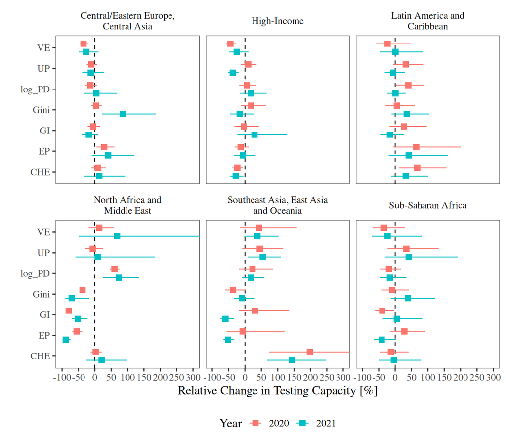

```r
b <- seq(-150, 300, 50)
b_l <- paste0(b, "%")

# Custom forest plot
p5 <- ggplot(results_regional[Predictors != "Intercept"],
             aes(color = Year,
                 y = Predictors)
) +
  facet_wrap(~ Region, labeller = labeller(Region = c(
    "High-Income" = "High-Income",
    "Central Europe, Eastern Europe, and Central Asia" = "Central/Eastern Europe,\nCentral Asia",
    "Latin America and Caribbean" = "Latin America and\nCaribbean",
    "North Africa and Middle East" = "North Africa and\nMiddle East",
    "Southeast Asia, East Asia, and Oceania" = "Southeast Asia, East Asia\nand Oceania",
    "Sub-Saharan Africa" = "Sub-Saharan Africa"
  ))) +
  scale_x_continuous(breaks = b
  ) +
  coord_cartesian(xlim = c(-100, 300)) +
  geom_vline(xintercept = 0,
             linetype = "dashed") +
  geom_point(aes(x = rel_change * 100,
                 group = Year),
             position = position_dodge2(width = 0.8,
                                        reverse = TRUE),
             shape = 15,
             size = 3
  ) +
  geom_linerange(aes(xmin = rel_change_2_5 * 100,
                     xmax = rel_change_97_5 * 100,
                     group = Year),
                 position = position_dodge2(width = 0.8,
                                            reverse = TRUE)
  ) +
  labs(x = "Relative Change in Testing Capacity [%]", y = "") +
  theme(legend.position = "bottom")

print(p5)
```

Save results

```r
ggsave(p5,
       filename = "tc_regional_forestplot.tiff",
       path = "paper/figures/",
       device = "tiff",
       width = 9,
       height = 7,
       dpi = 150)
```

## 4 Global COVID/MMR Vaccination (2021) & Mortality (2021) data

Create new data object.

```r
data_vacc <- copy(data)
data_vacc <- data_vacc[, .(
  Vaccination21 = as.integer(Vaccination21),
  Mortality20 = as.integer(Mortality20),
  Mortality21 = as.integer(Mortality21),
  location,
  Population,
  GBDR7,
  CHE = c(scale(CHE)),
  UP = c(scale(UP)),
  log_PD = c(scale(log_PD)),
  EP = c(scale(EP)),
  GI = c(scale(GI)),
  Gini = c(scale(Gini)),
  VE = c(scale(VE))
)]
```

### 4.1 Assemble data

[figure not shown]

Join MMR data to the remaining objects

```r
# Match data
v1 <- venn2(
  sort(unique(data$location)),
  sort(unique(mmr$Location)), plotte = FALSE
)

# Manually re-assign country names to complete matching
mmr$LocationMatched <- mmr$Location
mmr[grepl(pattern = "Bolivia", LocationMatched), LocationMatched := "Bolivia"]
mmr[grepl(pattern = "Côte d’Ivoire", LocationMatched), LocationMatched := "Cote d'Ivoire"]
mmr[grepl(pattern = "Czech", LocationMatched), LocationMatched := "Czech Republic"]
mmr[grepl(pattern = "Iran", LocationMatched), LocationMatched := "Iran"]
mmr[grepl(pattern = "Macedonia", LocationMatched), LocationMatched := "North Macedonia"]
mmr[grepl(pattern = "Russia", LocationMatched), LocationMatched := "Russia"]
mmr[grepl(pattern = "Republic of Korea", LocationMatched), LocationMatched := "South Korea"]
mmr[grepl(pattern = "Türkiye", LocationMatched), LocationMatched := "Turkey"]
mmr[grepl(pattern = "United Kingdom of Great Britain and Northern Ireland", LocationMatched), LocationMatched := "United Kingdom"]
mmr[grepl(pattern = "United States", LocationMatched), LocationMatched := "United States"]
mmr[grepl(pattern = "Viet", LocationMatched), LocationMatched := "Vietnam"]

# check whether everything matches
v2 <- venn2(
  sort(unique(data_vacc$location)),
  sort(unique(mmr$LocationMatched)),
  plotte = FALSE
)

# Match MMR data
mmr <-  dcast(
  mmr,
  ParentLocation + Location + LocationMatched ~ IndicatorCode,
  value.var = "Value")
m1 <- match(data_vacc$location, mmr$LocationMatched)
stopifnot(all(!is.na(m1)))

# Match the data
data_vacc[ , c("MCV1", "MCV2") := mmr[(m1), .(WHS8_110, MCV2)]]
```

I need to rescale the MMR vaccination data to contain count data for the model.

```r
data_vacc[, MCV2_per_100k := ((MCV2/100) * 100000)]
data_vacc[, Vaccination21 := as.integer(Vaccination21)]

# relevel region for fit and plotting reference
data_vacc$GBDR7 <- relevel(factor(data_vacc$GBDR7), 2)
```

Save data

```r
fwrite(x = data_vacc, file = "paper/tables/vaccination_data.csv")
```

## 5 Compare Vaccination MMR vs. Covid (2021)

### 5.1 Regression Vaccination (MMR & Covid)

```r
# Don't use the scaled GI, not necessary
non_correlated_indices <- c("CHE", "UP", "log_PD", "EP", "Gini", "GI", "VE")

# Main Model Formula
model_formula_cov <- paste0("Vaccination21 ~ 1 + GBDR7 + ",
                            paste(non_correlated_indices, collapse = " + "))
model_formula_mmr <- paste0("MCV2_per_100k ~ 1 + GBDR7 + ",
                            paste(non_correlated_indices, collapse = " + "))

# Model fit (including dispersion parameter theta estimation)
mod_negbin_cov <- glm.nb(formula = model_formula_cov, data = data_vacc)
mod_negbin_mmr <- glm.nb(formula = model_formula_mmr, data = data_vacc)

# Summary of each model to
mod_negbin_cov |> tidy(conf.int = TRUE, exponentiate = TRUE) |> kable()
```

| term | estimate | std.error | statistic | p.value | conf.low | conf.high |
| --- | --- | --- | --- | --- | --- | --- |
| (Intercept) | 5.377660e+04 | 0.1334696 | 81.6110569 | 0.0000000 | 4.162035e+04 | 6.988886e+04 |
| GBDR7Central Europe, Eastern Europe, and Central Asia | 8.163243e-01 | 0.1367190 | -1.4843847 | 0.1377069 | 6.223318e-01 | 1.070692e+00 |
| GBDR7Latin America and Caribbean | 1.205907e+00 | 0.2085225 | 0.8979001 | 0.3692388 | 8.104529e-01 | 1.791721e+00 |
| GBDR7North Africa and Middle East | 1.205536e+00 | 0.2026371 | 0.9224588 | 0.3562893 | 8.200197e-01 | 1.777764e+00 |
| GBDR7Southeast Asia, East Asia, and Oceania | 1.658662e+00 | 0.2523726 | 2.0050172 | 0.0449612 | 1.006289e+00 | 2.743038e+00 |
| GBDR7Sub-Saharan Africa | 5.236464e-01 | 0.2811349 | -2.3011680 | 0.0213821 | 3.030396e-01 | 9.029246e-01 |
| CHE | 1.036954e+00 | 0.0519240 | 0.6988538 | 0.4846434 | 9.343758e-01 | 1.153074e+00 |
| UP | 1.099114e+00 | 0.0689807 | 1.3700073 | 0.1706846 | 9.591504e-01 | 1.257886e+00 |
| log_PD | 9.619414e-01 | 0.0391239 | -0.9917650 | 0.3213122 | 8.907067e-01 | 1.038304e+00 |
| EP | 1.039508e+00 | 0.0412210 | 0.9399981 | 0.3472185 | 9.564841e-01 | 1.129656e+00 |
| Gini | 1.067535e+00 | 0.0562230 | 1.1623815 | 0.2450805 | 9.557162e-01 | 1.192370e+00 |
| GI | 7.569329e-01 | 0.1021905 | -2.7251118 | 0.0064280 | 6.174469e-01 | 9.303032e-01 |
| VE | 9.802802e-01 | 0.0767654 | -0.2594505 | 0.7952877 | 8.395777e-01 | 1.144946e+00 |

```r
mod_negbin_mmr |> tidy(conf.int = TRUE, exponentiate = TRUE) |> kable()
```

| term | estimate | std.error | statistic | p.value | conf.low | conf.high |
| --- | --- | --- | --- | --- | --- | --- |
| (Intercept) | 7.905114e+04 | 0.1278757 | 88.1938363 | 0.0000000 | 6.179081e+04 | 1.016317e+05 |
| GBDR7Central Europe, Eastern Europe, and Central Asia | 1.132123e+00 | 0.1314339 | 0.9441582 | 0.3450888 | 8.739866e-01 | 1.466901e+00 |
| GBDR7Latin America and Caribbean | 8.985547e-01 | 0.1975633 | -0.5414348 | 0.5882080 | 6.120069e-01 | 1.317856e+00 |
| GBDR7North Africa and Middle East | 1.268217e+00 | 0.1904112 | 1.2478903 | 0.2120712 | 8.746794e-01 | 1.843824e+00 |
| GBDR7Southeast Asia, East Asia, and Oceania | 1.074749e+00 | 0.2407925 | 0.2993733 | 0.7646552 | 6.735290e-01 | 1.720360e+00 |
| GBDR7Sub-Saharan Africa | 7.830440e-01 | 0.2719557 | -0.8992875 | 0.3684995 | 4.617818e-01 | 1.327003e+00 |
| CHE | 1.026481e+00 | 0.0490924 | 0.5324017 | 0.5944478 | 9.343972e-01 | 1.129307e+00 |
| UP | 9.459812e-01 | 0.0663669 | -0.8367508 | 0.4027327 | 8.303433e-01 | 1.076654e+00 |
| log_PD | 1.047704e+00 | 0.0374025 | 1.2459334 | 0.2127889 | 9.723961e-01 | 1.128009e+00 |
| EP | 9.973850e-01 | 0.0392405 | -0.0667282 | 0.9467981 | 9.234029e-01 | 1.076973e+00 |
| Gini | 1.092301e+00 | 0.0560606 | 1.5748356 | 0.1152944 | 9.764551e-01 | 1.222290e+00 |
| GI | 9.101762e-01 | 0.0957745 | -0.9826945 | 0.3257578 | 7.562028e-01 | 1.098376e+00 |
| VE | 9.549019e-01 | 0.0722078 | -0.6390816 | 0.5227698 | 8.295223e-01 | 1.099820e+00 |

```r
# Save the coefficients
mod_negbin_cov_coefs <- cbind(
  mod_negbin_cov |> tidy() |> as.data.table(),
  confint(mod_negbin_cov)
)
mod_negbin_mmr_coefs <- cbind(
  mod_negbin_mmr |> tidy() |> as.data.table(),
  confint(mod_negbin_mmr)
)

# join data for plotting
mod_negbin_cov_coefs[, Vaccination := "Covid"]
mod_negbin_mmr_coefs[, Vaccination := "MMR"]
mod_negbin_vacc_coefs <- rbindlist(list(mod_negbin_cov_coefs, mod_negbin_mmr_coefs))

# Transform estimates and CI to Incidence Rate Ratio (% increase/decrease from base)
mod_negbin_vacc_coefs[, `:=`(exp_estimate = exp(estimate),
                             exp_2_5 = exp(`2.5 %`),
                             exp_97_5 = exp(`97.5 %`))]

# Calculate the relative change in testing by each predictor increase
mod_negbin_vacc_coefs[, `:=`(rel_change  = exp_estimate - 1,
                             rel_change_2_5 = exp_2_5 - 1,
                             rel_change_97_5 = exp_97_5 - 1)]

# Create ordered factor to improve plotting
mod_negbin_vacc_coefs[, term := factor(
  term,
  ordered = T,
  levels = c(
    "(Intercept)",
    "GBDR7Central Europe, Eastern Europe, and Central Asia",
    "GBDR7Latin America and Caribbean",
    "GBDR7North Africa and Middle East",
    "GBDR7Southeast Asia, East Asia, and Oceania",
    "GBDR7Sub-Saharan Africa",
    "CHE",
    "GI",
    "Gini",
    "VE",
    "EP",
    "log_PD",
    "UP"
  ) |> rev(),
  labels = c(
    "(Intercept)",
    "GBDR7\n(Central/Eastern Europe, and Central Asia)",
    "GBDR7\n(Latin America and Caribbean)",
    "GBDR7\n(North Africa and Middle East)",
    "GBDR7\n(Southeast Asia, East Asia, and Oceania)",
    "GBDR7\n(Sub-Saharan Africa)",
    "CHE",
    "GI",
    "Gini",
    "VE",
    "EP",
    "log(PD)",
    "UP"
  ) |> rev(),
)]
```

```r
fwrite(mod_negbin_vacc_coefs[, .(
  Vaccination,
  Predictor = term,
  effect_estimate = estimate,
  standard_error = std.error,
  test_statistic = statistic,
  p_value = p.value,
  confidence_interval_lower = `2.5 %`,
  confidence_interval_upper = `97.5 %`,
  relative_change = format(rel_change, scientific = F),
  relative_change_lower_ci = format(rel_change_2_5, scientific = F),
  relative_change_upper_ci = format(rel_change_97_5, scientific = F))
],
file = "paper/tables/vaccination_global_regression_sumstats.csv"
)
```

#### 5.1.1 Forestplot

Plot the results. Reference group for the Region effects is “High-Income”. Displayed effects are independent of region and other indices and represent a global trend.

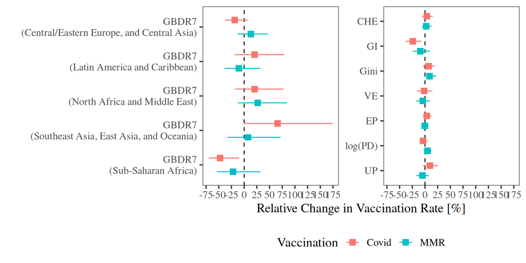

```r
# create dummy factor for facetting
mod_negbin_vacc_coefs[, facet_dum := ifelse(grepl("GBDR7|Intercept", term), "A", "B")]

# Custom breaks for the x axis to make effect size clear
b <- seq(-150, 175, 25)

# Custom forest plot
p6 <- ggplot(mod_negbin_vacc_coefs[term != "(Intercept)"],
             aes(color = Vaccination,
                 y = term)
) +
  facet_wrap(~facet_dum, scales = "free_y") +
  geom_vline(xintercept = 0,
             linetype = "dashed") +
  geom_point(aes(x = rel_change * 100,
                 group = Vaccination),
             position = position_dodge2(width = 0.8, reverse = TRUE),
             shape = 15,
             size = 3
  ) +
  geom_linerange(aes(xmin = rel_change_2_5 * 100,
                     xmax = rel_change_97_5 * 100,
                     group = Vaccination),
                 position = position_dodge2(width = 0.8, reverse = TRUE)
  ) +
  labs(x = "Relative Change in Vaccination Rate [%]", y = "") +
  scale_x_continuous(breaks = b) +
  theme(legend.position = "bottom",
        strip.text = element_blank())

print(p6)
```

```r
ggsave(p6,
       filename = "vacc_global_forestplot.tiff",
       path = "paper/figures/",
       device = "tiff",
       width = 10,
       height = 4,
       dpi = 150)
```

### 5.2 Regional vaccination regression 2021

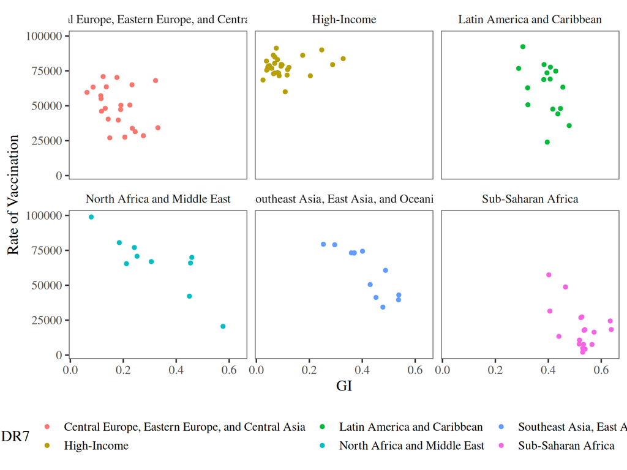

```r
# Model wants integers
data$Vaccination21 <- as.integer(data$Vaccination21)
ggplot(data, aes(y = Vaccination21, x = GI, col = GBDR7)) +
  facet_wrap(~GBDR7) +
  geom_point() +
  labs(y = "Rate of Vaccination") +
  theme(legend.position = "bottom")
```

```r
# Create a object listing all models to fit
regional_tests <- data_model_long[, expand.grid(
  Region = unique(GBDR7),
  Predictors = paste(non_correlated_indices, collapse = " + "),
  stringsAsFactors = FALSE)
] |> as.data.table()
regional_tests[, index := 1:.N]
model_list <- vector("list", nrow(regional_tests))
names(model_list) <- paste(regional_tests$Region, regional_tests$Year, sep = ": ")

# Save results for each predictor in year and region
results_vacc_regional <- data_model_long[, expand.grid(
  Region = unique(GBDR7),
  Predictors = c("Intercept", non_correlated_indices),
  stringsAsFactors = FALSE)
] |> as.data.table()

# create columns for all parameter estimates
results_vacc_regional[, c("estimate", "std_error",
                          "test_statistic", "p_value",
                          "ci95_lower", "ci95_upper", "dispersion") := numeric()]
results_vacc_regional$convergence <- logical()
results_vacc_regional$warning <- character()
```

Loop through each region and test for association

```r
for (i in regional_tests$index) {

  # i <- 2
  this_region <- regional_tests[index == (i), Region]
  this_predictor_set <- regional_tests[index == (i), Predictors]
  this_model_formula <- paste0(
    "Vaccination21 ~ 1 + ",
    this_predictor_set) |>
    as.formula()

  # Get regression estimates for tests ~ index in year & region
  mod <- glm.nb(formula = this_model_formula, control = glm.control(maxit = 32),
                data = data[GBDR7 == (this_region), ]
  )

  # Make the assignment cleaner
  num_predictors <- length(coef(mod))
  clean_coefficients <- cbind(
    tidy(mod)[1:num_predictors, 2:5],
    tryCatch(confint(mod)[1:num_predictors, ],
             error = function(e){

               res <- data.frame(x = rep(NA, num_predictors),
                                 y = rep(NA, num_predictors))
               colnames(res) <- c("2.5 %", "97.5 %")
               rownames(res) <- c("(Intercept)", "CHE",
                                  "UP", "log_PD", "Gini",
                                  "EP", "GI", "VE")

               # Apparently the intercept is the problem here, just omit it!
               res[c(2:num_predictors), ] <- confint(mod, parm = non_correlated_indices)
               return(res)
             }))
  rownames(clean_coefficients)[1] <- "Intercept"

  # Save the model for plotting
  model_list[[i]] <- mod

  # Ensure rows are added correctly for each predictor
  predictor_order <- results_vacc_regional[Region == (this_region), Predictors]

  # I want results in a nice format
  results_vacc_regional[Region == (this_region), c(
    "estimate",
    "std_error",
    "test_statistic",
    "p_value",
    "ci95_lower",
    "ci95_upper"
  ) := clean_coefficients[(predictor_order), ]]

  # Add dispersion and model information
  results_vacc_regional[Region == (this_region),
                        dispersion := mod$theta]
  results_vacc_regional[Region == (this_region),
                        warning := ifelse(is.null(mod$th.warn), NA, mod$th.warn)]
  results_vacc_regional[Region == (this_region),
                        convergence := mod$converged]
}
```

Transform results to relative change

```r
# Transform estimates and CI to Incidence Rate Ratio (% increase/decrease from base)
results_vacc_regional[, `:=`(rel_change = exp(estimate) - 1,
                             rel_change_2_5 = exp(ci95_lower) - 1,
                             rel_change_97_5 = exp(ci95_upper) - 1)]

# refactor for facet order
results_vacc_regional$Region <- relevel(factor(results_vacc_regional$Region), 2)
```

Save.

```r
fwrite(results_vacc_regional[, .(
  GBDR7 = Region,
  Predictor = Predictors,
  effect_estimate = estimate,
  standard_error = std_error,
  test_statistic = test_statistic,
  p_value = p_value,
  confidence_interval_lower = ci95_lower,
  confidence_interval_upper = ci95_upper,
  dispersion_parameter = dispersion,
  relative_change = format(rel_change, scientific = F),
  relative_change_lower_ci = format(rel_change_2_5, scientific = F),
  relative_change_upper_ci = format(rel_change_97_5, scientific = F))
],
file = "paper/tables/vaccination_covid_regional_regression_sumstats.csv"
)
```

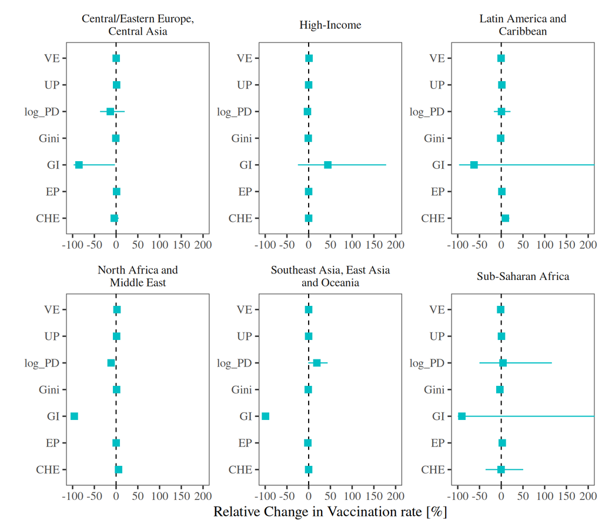

```r
b <- seq(-150, 300, 50)
b_l <- paste0(b, "%")

# Custom forest plot
p7 <- ggplot(results_vacc_regional[Predictors != "Intercept"],
             aes(y = Predictors)
) +
  facet_wrap(~ Region, scales = "free",
             labeller = labeller(Region = c(
               "High-Income" = "High-Income",
               "Central Europe, Eastern Europe, and Central Asia" = "Central/Eastern Europe,\nCentral Asia",
               "Latin America and Caribbean" = "Latin America and\nCaribbean",
               "North Africa and Middle East" = "North Africa and\nMiddle East",
               "Southeast Asia, East Asia, and Oceania" = "Southeast Asia, East Asia\nand Oceania",
               "Sub-Saharan Africa" = "Sub-Saharan Africa"
             ))) +
  scale_x_continuous(breaks = b) +
  coord_cartesian(xlim = c(-100, 200)) +
  geom_vline(xintercept = 0,
             linetype = "dashed") +
  geom_point(aes(x = rel_change * 100),
             position = position_dodge2(width = 0.8,
                                        reverse = TRUE),
             shape = 15,
             size = 3,
             col = scales::hue_pal()(2)[2]
  ) +
  geom_linerange(aes(xmin = rel_change_2_5 * 100,
                     xmax = rel_change_97_5 * 100),
                 position = position_dodge2(width = 0.8,
                                            reverse = TRUE),
                 col = scales::hue_pal()(2)[2]
  ) +
  labs(x = "Relative Change in Vaccination rate [%]", y = "") +
  theme(legend.position = "bottom")

print(p7)
```

Save plot.

```r
ggsave(p7,
       filename = "vacc_regional_forestplot.tiff",
       path = "paper/figures/",
       device = "tiff",
       width = 9,
       height = 7,
       dpi = 150)
```

## 6 Mortality Regression 2021

### 6.1 Frequentist Fit

Frequentist model for 2020 does not converge!

```r
# Model Fit
model_mortality_21 <- paste0("Mortality21 ~ 1 + GBDR7 + ",
                             paste(non_correlated_indices, collapse = " + "))
mod_mortality_21 <- glm.nb(formula = model_mortality_21, data = data_vacc)

# Save the coefficients
mod_mortality_21_coefs <- cbind(
  mod_mortality_21 |> tidy() |> as.data.table(),
  confint(mod_mortality_21)
)

# Transform estimates and CI to Incidence Rate Ratio (% increase/decrease from base)
mod_mortality_21_coefs[, `:=`(exp_estimate = exp(estimate),
                              exp_2_5 = exp(`2.5 %`),
                              exp_97_5 = exp(`97.5 %`))]

# Calculate the relative change in testing by each predictor increase
mod_mortality_21_coefs[, `:=`(rel_change  = exp_estimate - 1,
                              rel_change_2_5 = exp_2_5 - 1,
                              rel_change_97_5 = exp_97_5 - 1)]

# Create ordered factor to improve plotting
mod_mortality_21_coefs[, term := factor(
  term,
  ordered = T,
  levels = c(
    "(Intercept)",
    "GBDR7Central Europe, Eastern Europe, and Central Asia",
    "GBDR7Latin America and Caribbean",
    "GBDR7North Africa and Middle East",
    "GBDR7Southeast Asia, East Asia, and Oceania",
    "GBDR7Sub-Saharan Africa",
    "CHE",
    "GI",
    "Gini",
    "VE",
    "EP",
    "log_PD",
    "UP"
  ) |> rev(),
  labels = c(
    "(Intercept)",
    "GBDR7\n(Central/Eastern Europe, and Central Asia)",
    "GBDR7\n(Latin America and Caribbean)",
    "GBDR7\n(North Africa and Middle East)",
    "GBDR7\n(Southeast Asia, East Asia, and Oceania)",
    "GBDR7\n(Sub-Saharan Africa)",
    "CHE",
    "GI",
    "Gini",
    "VE",
    "EP",
    "log(PD)",
    "UP"
  ) |> rev()
)]

# create dummy factor for facetting
mod_mortality_21_coefs[, facet_dum := ifelse(grepl("GBDR7|Intercept", term), "A", "B")]
```

Save results.

```r
fwrite(mod_mortality_21_coefs[, .(
  Predictor = term,
  effect_estimate = estimate,
  standard_error = std.error,
  test_statistic = statistic,
  p_value = p.value,
  confidence_interval_lower = `2.5 %`,
  confidence_interval_upper = `97.5 %`,
  relative_change = format(rel_change, scientific = F),
  relative_change_lower_ci = format(rel_change_2_5, scientific = F),
  relative_change_upper_ci = format(rel_change_97_5, scientific = F))
],
file = "paper/tables/mortality_2021_global_regression_sumstats.csv"
)
```

### 6.2 Forestplot

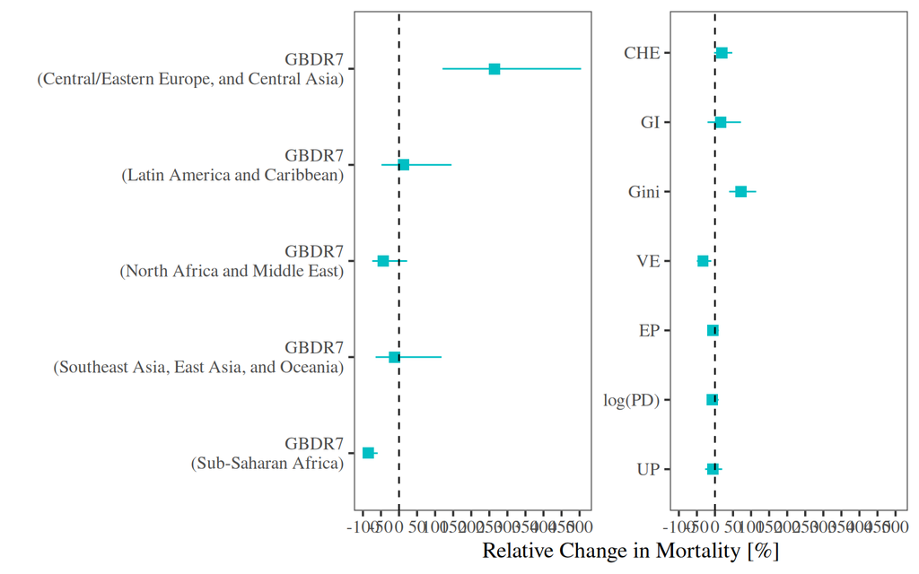

```r
# Custom breaks for the x axis to make effect size clear
b <- seq(-150, 600, 50)

# Custom forest plot
p8 <- ggplot(mod_mortality_21_coefs[term != "(Intercept)"],
             aes(y = term)
) +
  facet_wrap(~facet_dum, scales = "free_y") +
  geom_point(aes(x = rel_change * 100),
             position = position_dodge2(width = 0.8, reverse = TRUE),
             shape = 15,
             size = 3,
             col = scales::hue_pal()(2)[2]
  ) +
  geom_linerange(aes(xmin = rel_change_2_5 * 100,
                     xmax = rel_change_97_5 * 100),
                 col = scales::hue_pal()(2)[2]# 2021 color
  ) +
  geom_vline(xintercept = 0,
             linetype = "dashed") +
  labs(x = "Relative Change in Mortality [%]", y = "") +
  scale_x_continuous(breaks = b) +
  theme(legend.position = "bottom",
        strip.text = element_blank())

print(p8)
```

Save plot.

```r
ggsave(p8,
       filename = "mortality_global_forestplot.tiff",
       path = "paper/figures/",
       device = "tiff",
       width = 12,
       height = 4,
       dpi = 150)
```

### 6.3 Bayesian Fit 2020 & 2021

```r
# Main Model Formula
model_mortality_20 <- paste0("Mortality20 ~ 1 + GBDR7 + ",
                             paste(non_correlated_indices, collapse = " + "))
model_mortality_21 <- paste0("Mortality21 ~ 1 + GBDR7 + ",
                             paste(non_correlated_indices, collapse = " + "))

# fit model
stan_20 <- stan_glm(formula = model_mortality_20,
                    family = neg_binomial_2(link = "log"),
                    data = data_vacc)
stan_21 <- stan_glm(formula = model_mortality_21,
                    family = neg_binomial_2(link = "log"),
                    data = data_vacc)
# Get coefficients from the model
mod_mort_coefs <- data.table(
  year = rep(c("2020", "2021"), each = length(coef(stan_21))),
  coef = c(names(coef(stan_20)), names(coef(stan_21))),
  estimate = c(coef(stan_20), coef(stan_21))
)
tmp <- rbindlist(
  list(
    as.data.frame(posterior_interval(stan_20)[c(1:13), ]),
    as.data.frame(posterior_interval(stan_21)[c(1:13), ])
  )
)
mod_mort_coefs[, c("lci", "uci") := tmp]

# Transform estimates and CI to Incidence Rate Ratio (% increase/decrease from base)
mod_mort_coefs[, `:=`(exp_estimate = exp(estimate),
                      exp_2_5 = exp(lci),
                      exp_97_5 = exp(uci))]

# Calculate the relative change in testing by each predictor increase
mod_mort_coefs[, `:=`(rel_change  = exp_estimate - 1,
                      rel_change_2_5 = exp_2_5 - 1,
                      rel_change_97_5 = exp_97_5 - 1)]

# Create ordered factor to improve plotting
mod_mort_coefs[, term := factor(
  coef,
  ordered = T,
  levels = c(
    "(Intercept)",
    "GBDR7Central Europe, Eastern Europe, and Central Asia",
    "GBDR7Latin America and Caribbean",
    "GBDR7North Africa and Middle East",
    "GBDR7Southeast Asia, East Asia, and Oceania",
    "GBDR7Sub-Saharan Africa",
    "CHE",
    "GI",
    "Gini",
    "VE",
    "EP",
    "log_PD",
    "UP"
  ) |> rev(),
  labels = c(
    "(Intercept)",
    "GBDR7\n(Central/Eastern Europe, and Central Asia)",
    "GBDR7\n(Latin America and Caribbean)",
    "GBDR7\n(North Africa and Middle East)",
    "GBDR7\n(Southeast Asia, East Asia, and Oceania)",
    "GBDR7\n(Sub-Saharan Africa)",
    "CHE",
    "GI",
    "Gini",
    "VE",
    "EP",
    "log(PD)",
    "UP"
  ) |> rev()
)]

# create dummy factor for facetting
mod_mort_coefs[, facet_dum := ifelse(grepl("GBDR7|Intercept", term), "A", "B")]

#
mod_mort_coefs |> kable()
```

| year | coef | estimate | lci | uci | exp_estimate | exp_2_5 | exp_97_5 | rel_change | rel_change_2_5 | rel_change_97_5 | term | facet_dum |
| --- | --- | --- | --- | --- | --- | --- | --- | --- | --- | --- | --- | --- |
| 2020 | (Intercept) | 3.5205384 | 2.9038952 | 4.1635985 | 33.8026214 | 18.2450750 | 64.3025017 | 32.8026214 | 17.2450750 | 63.3025017 | (Intercept) | A |
| 2020 | GBDR7Central Europe, Eastern Europe, and Central Asia | 0.7346395 | 0.0865150 | 1.3885463 | 2.0847303 | 1.0903677 | 4.0090180 | 1.0847303 | 0.0903677 | 3.0090180 | GBDR7 (Central/Eastern Europe, and Central Asia) | A |
| 2020 | GBDR7Latin America and Caribbean | 0.6890342 | -0.3201826 | 1.6872325 | 1.9917909 | 0.7260165 | 5.4045032 | 0.9917909 | -0.2739835 | 4.4045032 | GBDR7 (Latin America and Caribbean) | A |
| 2020 | GBDR7North Africa and Middle East | -0.5005729 | -1.4526363 | 0.5175628 | 0.6061833 | 0.2339527 | 1.6779332 | -0.3938167 | -0.7660473 | 0.6779332 | GBDR7 (North Africa and Middle East) | A |
| 2020 | GBDR7Southeast Asia, East Asia, and Oceania | -1.5111620 | -2.8928660 | -0.1946124 | 0.2206534 | 0.0554172 | 0.8231536 | -0.7793466 | -0.9445828 | -0.1768464 | GBDR7 (Southeast Asia, East Asia, and Oceania) | A |
| 2020 | GBDR7Sub-Saharan Africa | -2.3004579 | -3.6066352 | -0.9751020 | 0.1002129 | 0.0271430 | 0.3771539 | -0.8997871 | -0.9728570 | -0.6228461 | GBDR7 (Sub-Saharan Africa) | A |
| 2020 | CHE | 0.3059055 | 0.0514280 | 0.5660098 | 1.3578540 | 1.0527734 | 1.7612254 | 0.3578540 | 0.0527734 | 0.7612254 | CHE | B |
| 2020 | UP | 0.2337742 | -0.1423161 | 0.6004241 | 1.2633593 | 0.8673471 | 1.8228918 | 0.2633593 | -0.1326529 | 0.8228918 | UP | B |
| 2020 | log_PD | 0.1181872 | -0.1069370 | 0.3295521 | 1.1254547 | 0.8985823 | 1.3903453 | 0.1254547 | -0.1014177 | 0.3903453 | log(PD) | B |
| 2020 | EP | -0.2969296 | -0.4941424 | -0.1002357 | 0.7430963 | 0.6100939 | 0.9046242 | -0.2569037 | -0.3899061 | -0.0953758 | EP | B |
| 2020 | Gini | 0.2517650 | 0.0127792 | 0.5001743 | 1.2862937 | 1.0128612 | 1.6490087 | 0.2862937 | 0.0128612 | 0.6490087 | Gini | B |
| 2020 | GI | -0.0044053 | -0.4895309 | 0.5061826 | 0.9956044 | 0.6129139 | 1.6589462 | -0.0043956 | -0.3870861 | 0.6589462 | GI | B |
| 2020 | VE | -0.0660209 | -0.4424939 | 0.3153243 | 0.9361113 | 0.6424322 | 1.3707038 | -0.0638887 | -0.3575678 | 0.3707038 | VE | B |
| 2021 | (Intercept) | 4.2353147 | 3.8031484 | 4.6694055 | 69.0834186 | 44.8421446 | 106.6343244 | 68.0834186 | 43.8421446 | 105.6343244 | (Intercept) | A |
| 2021 | GBDR7Central Europe, Eastern Europe, and Central Asia | 1.2904805 | 0.8449638 | 1.7486027 | 3.6345326 | 2.3278934 | 5.7465672 | 2.6345326 | 1.3278934 | 4.7465672 | GBDR7 (Central/Eastern Europe, and Central Asia) | A |
| 2021 | GBDR7Latin America and Caribbean | 0.1308111 | -0.5694505 | 0.8307600 | 1.1397525 | 0.5658363 | 2.2950624 | 0.1397525 | -0.4341637 | 1.2950624 | GBDR7 (Latin America and Caribbean) | A |
| 2021 | GBDR7North Africa and Middle East | -0.5566875 | -1.2496386 | 0.1751598 | 0.5731043 | 0.2866084 | 1.1914366 | -0.4268957 | -0.7133916 | 0.1914366 | GBDR7 (North Africa and Middle East) | A |
| 2021 | GBDR7Southeast Asia, East Asia, and Oceania | -0.1289880 | -0.9386483 | 0.7187535 | 0.8789845 | 0.3911562 | 2.0518740 | -0.1210155 | -0.6088438 | 1.0518740 | GBDR7 (Southeast Asia, East Asia, and Oceania) | A |
| 2021 | GBDR7Sub-Saharan Africa | -1.9253703 | -2.8168218 | -0.9735272 | 0.1458218 | 0.0597957 | 0.3777483 | -0.8541782 | -0.9402043 | -0.6222517 | GBDR7 (Sub-Saharan Africa) | A |
| 2021 | CHE | 0.1833986 | -0.0068249 | 0.3784150 | 1.2012932 | 0.9931984 | 1.4599687 | 0.2012932 | -0.0068016 | 0.4599687 | CHE | B |
| 2021 | UP | -0.0699567 | -0.2976254 | 0.1567540 | 0.9324342 | 0.7425795 | 1.1697079 | -0.0675658 | -0.2574205 | 0.1697079 | UP | B |
| 2021 | log_PD | -0.0743324 | -0.2285292 | 0.0772831 | 0.9283631 | 0.7957031 | 1.0803479 | -0.0716369 | -0.2042969 | 0.0803479 | log(PD) | B |
| 2021 | EP | -0.0494634 | -0.1948463 | 0.0890442 | 0.9517400 | 0.8229611 | 1.0931290 | -0.0482600 | -0.1770389 | 0.0931290 | EP | B |
| 2021 | Gini | 0.5451086 | 0.3537017 | 0.7318167 | 1.7247957 | 1.4243302 | 2.0788537 | 0.7247957 | 0.4243302 | 1.0788537 | Gini | B |
| 2021 | GI | 0.1541114 | -0.1964535 | 0.5080021 | 1.1666208 | 0.8216395 | 1.6619674 | 0.1666208 | -0.1783605 | 0.6619674 | GI | B |
| 2021 | VE | -0.4110213 | -0.6682788 | -0.1482712 | 0.6629728 | 0.5125901 | 0.8621972 | -0.3370272 | -0.4874099 | -0.1378028 | VE | B |

### 6.4 Forestplot

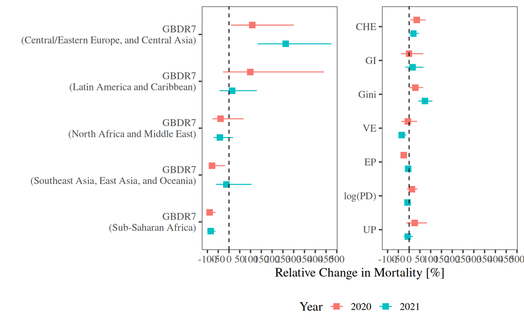

```r
# Custom breaks for the x axis to make effect size clear
b <- seq(-150, 600, 50)

# Custom forest plot
ggplot(mod_mort_coefs[term != "(Intercept)"],
       aes(color = year,
           y = term)
) +
  facet_wrap(~facet_dum, scales = "free_y") +
  geom_point(aes(x = rel_change * 100,
                 group = year),
             position = position_dodge2(width = 0.8, reverse = TRUE),
             shape = 15,
             size = 3
  ) +
  geom_linerange(aes(xmin = rel_change_2_5 * 100,
                     xmax = rel_change_97_5 * 100,
                     group = year),
                 position = position_dodge2(width = 0.8, reverse = TRUE)
  ) +
  geom_vline(xintercept = 0,
             linetype = "dashed") +
  guides(color = guide_legend(title = "Year")) +
  labs(x = "Relative Change in Mortality [%]", y = "") +
  scale_x_continuous(breaks = b) +
  theme(legend.position = "bottom",
        strip.text = element_blank())
```